# Statistical inference

# 15. Statistical inference

```r
library(tidyverse)
library(dslabs)
library(ggplot2)
```

## 15.6 Confidence intervals

Confidence intervals are a very useful concept widely employed by data analysts. For R, we can use geometry `geom_smooth` from `ggplot`. If the interval you submitted includes the p, you get half the money you spent on your “poll” back and pass to the next stage of the competition. However, with an interval this big, we have no chance of winning the competition. Even a smaller interval, such as saying the spread will be between -10 and 10%, will not be considered serious. On the other hand, the smaller the interval we report, the smaller our chances are of winning the prize. Likewise, a bold pollster that reports very small intervals and misses the mark most of the time will not be considered a good pollster. If we are asked to create an interval with, say, a 95% chance of including p, we can do that as well. These are called 95% confidence intervals. We want to know the probability that the interval $[\bar{X}-2\hat{SE}(\bar{X}),\bar{X}+2\hat{SE}(\bar{X})]$ contains the true proportion p. First, consider that the start and end of these intervals are random variables. To illustrate this, run the Monte Carlo simulation above twice. We use the same parameters as above:

```r
p <- 0.45
N <- 1000
```

```r
x <- sample(c(0, 1), size = N, replace = TRUE, prob = c(1-p, p))
x_hat <- mean(x)
se_hat <- sqrt(x_hat * (1 - x_hat) / N)
c(x_hat - 1.96 * se_hat, x_hat + 1.96 * se_hat)
```

```
[1] 0.4092336 0.4707664
```

```r
x <- sample(c(0,1), size=N, replace=TRUE, prob=c(1-p, p))
x_hat <- mean(x)
se_hat <- sqrt(x_hat * (1 - x_hat) / N)
c(x_hat - 1.96 * se_hat, x_hat + 1.96 * se_hat)
```

```
[1] 0.4181713 0.4798287
```

For x above
$$P(\bar{X}-1.96\hat{SE}(\bar{X})\le p\le\bar{X}+1.96\hat{SE}(\bar{X}))$$

Or,
$$P(-1.96\le\frac{\bar{X}-p}{\hat{SE}(\bar{X})}\le1.96)$$

If we replace $\frac{\bar{X}-p}{\hat{SE}(\bar{X})}$ as Z,
$$P(-1.96\le Z\le1.96)$$

this can be computed;

```r
pnorm(1.96) - pnorm(-1.96)
```

```
[1] 0.9500042
```

If we want probability of 99%,
$$P(-z\le Z\le z)=0.99$$
Using:

```r
z <- qnorm(0.995)
z
```

```
[1] 2.575829
```

As a consequence, we have that:

```r
pnorm(z) - pnorm(-z)
```

```
[1] 0.99
```

Any proportion of p we can assign z as `z = qnorm(1 - (1 - p)/2)`. For p = 0.95,

```r
qnorm(0.975)
```

```
[1] 1.959964
```

### 15.6.1 A Monte Carlo simulation

We can run a Monte Carlo simulation to confirm that, in fact, a 95% confidence interval includes p 95% of the time.

```r
N <- 1000
B <- 10000
inside <- replicate(B, {
  x <- sample(c(0,1), size = N, replace = TRUE, prob = c(1-p, p))
  x_hat <- mean(x)
  se_hat <- sqrt(x_hat * (1 - x_hat) / N)
  between(p, x_hat - 1.96 * se_hat, x_hat + 1.96 * se_hat)
})
mean(inside)
```

```
[1] 0.9501
```

```
N <- 1000
B <- 100
inside = rep(1, 100, 1)
as.data.frame(inside)
x <- replicate(B, {
  x <- sample(c(0,1), size = N, replace = TRUE, prob = c(1-p, p))
})

inside %>%
  mutate(x_hat = mean(x)) %>%
  mutate(se_hat = sqrt(x_hat * (1 - x_hat) / N)) %>%
  mutate(p_inside = ifelse(
      between(p,
              x_hat - 1.96 * se_hat,
              x_hat + 1.96 * se_hat),
      "Yes",
      "No"))
```

## 15.7 Exercises

For these exercises, we will use actual polls from the 2016 election. You can load the data from the dslabs package.

```r
data("polls_us_election_2016")
```

Specifically, we will use all the national polls that ended within one week before the election.

```r
polls <- polls_us_election_2016 %>%
  filter(enddate >= "2016-10-31" & state == "U.S.")
```

1. For the first poll, you can obtain the samples size and estimated Clinton percentage with:

```r
N <- polls$samplesize[1]
x_hat <- polls$rawpoll_clinton[1]/100
```

Assume there are only two candidates and construct a 95% confidence interval for the election night proportion p.

```r
se_hat <- sqrt(x_hat*(1-x_hat)/N)
c(x_hat - 1.96 * se_hat, x_hat + 1.96 * se_hat)
```

```
[1] 0.4492381 0.4907619
```

2. Now use `dplyr` to add a confidence interval as two columns, call them `lower` and `upper`, to the object `poll`. Then use `select` to show the `pollster`, `enddate`, `x_hat`,`lower`, `upper` variables. Hint: define temporary columns `x_hat` and `se_hat.`

```r
polls <- polls %>%
  mutate(x_hat = rawpoll_clinton/100,
         se_hat = sqrt(x_hat*(1-x_hat)/samplesize),
         lower = x_hat - 1.96 * se_hat,
         upper = x_hat + 1.96 * se_hat)
polls %>% select(pollster, enddate, x_hat, se_hat, lower, upper) %>% head()
```

|  | pollster | enddate | x_hat | se_hat | lower | upper |
| --- | --- | --- | --- | --- | --- | --- |
| 1 | ABC News/Washington Post | 2016-11-06 | 0.4700 | 0.010592790 | 0.4492381 | 0.4907619 |
| 2 | Google Consumer Surveys | 2016-11-07 | 0.3803 | 0.002978005 | 0.3744631 | 0.3861369 |
| 3 | Ipsos | 2016-11-06 | 0.4200 | 0.010534681 | 0.3993520 | 0.4406480 |
| 4 | YouGov | 2016-11-07 | 0.4500 | 0.008204286 | 0.4339196 | 0.4660804 |
| 5 | Gravis Marketing | 2016-11-06 | 0.4700 | 0.003869218 | 0.4624163 | 0.4775837 |
| 6 | Fox News/Anderson Robbins Research/Shaw & Company Research | 2016-11-06 | 0.4800 | 0.013883131 | 0.4527891 | 0.5072109 |

3. The final tally for the popular vote was Clinton 48.2% and Trump 46.1%. Add a column, call it `hit`, to the previous table stating if the confidence interval included the true proportion p=0.482 or not.

```r
p = 0.482
polls <- polls %>%
  mutate(hit = ifelse(p >= lower & p <= upper, T, F))
head(polls)
```

|  | state | startdate | enddate | pollster | grade | samplesize | population | rawpoll_clinton | rawpoll_trump | rawpoll_johnson | rawpoll_mcmullin | adjpoll_clinton | adjpoll_trump | adjpoll_johnson | adjpoll_mcmullin | x_hat | se_hat | lower | upper | hit |
| --- | --- | --- | --- | --- | --- | --- | --- | --- | --- | --- | --- | --- | --- | --- | --- | --- | --- | --- | --- | --- |
| 1 | U.S. | 2016-11-03 | 2016-11-06 | ABC News/Washington Post | A+ | 2220 | lv | 47.00 | 43.00 | 4.00 | NA | 45.20163 | 41.72430 | 4.626221 | NA | 0.4700 | 0.010592790 | 0.4492381 | 0.4907619 | TRUE |
| 2 | U.S. | 2016-11-01 | 2016-11-07 | Google Consumer Surveys | B | 26574 | lv | 38.03 | 35.69 | 5.46 | NA | 43.34557 | 41.21439 | 5.175792 | NA | 0.3803 | 0.002978005 | 0.3744631 | 0.3861369 | FALSE |
| 3 | U.S. | 2016-11-02 | 2016-11-06 | Ipsos | A- | 2195 | lv | 42.00 | 39.00 | 6.00 | NA | 42.02638 | 38.81620 | 6.844734 | NA | 0.4200 | 0.010534681 | 0.3993520 | 0.4406480 | FALSE |
| 4 | U.S. | 2016-11-04 | 2016-11-07 | YouGov | B | 3677 | lv | 45.00 | 41.00 | 5.00 | NA | 45.65676 | 40.92004 | 6.069454 | NA | 0.4500 | 0.008204286 | 0.4339196 | 0.4660804 | FALSE |
| 5 | U.S. | 2016-11-03 | 2016-11-06 | Gravis Marketing | B- | 16639 | rv | 47.00 | 43.00 | 3.00 | NA | 46.84089 | 42.33184 | 3.726098 | NA | 0.4700 | 0.003869218 | 0.4624163 | 0.4775837 | FALSE |
| 6 | U.S. | 2016-11-03 | 2016-11-06 | Fox News/Anderson Robbins Research/Shaw & Company Research | A | 1295 | lv | 48.00 | 44.00 | 3.00 | NA | 49.02208 | 43.95631 | 3.057876 | NA | 0.4800 | 0.013883131 | 0.4527891 | 0.5072109 | TRUE |

4. For the table you just created, what proportion of confidence intervals included p?

```r
a <- count(polls, hit) %>% filter(hit == T) %>% .$n
b <- count(polls)$n
a/b
```

```
[1] 0.3142857
```

5. If these confidence intervals are constructed correctly, and the theory holds up, what proportion should include p?: 95%
6. A much smaller proportion of the polls than expected produce confidence intervals containing p. If you look closely at the table, you will see that most polls that fail to include p are underestimating. The reason for this is undecided voters, individuals polled that do not yet know who they will vote for or do not want to say. Because, historically, undecideds divide evenly between the two main candidates on election day, it is more informative to estimate the spread or the difference between the proportion of two candidates d, which in this election was 0.482-0.461=0.021. Assume that there are only two parties and that d=2p-1, redefine `polls` as below and re-do exercise 1, but for the difference.

```r
polls <- polls_us_election_2016 %>%
  filter(enddate >= "2016-10-31" & state == "U.S.")  %>%
  mutate(x_hat = rawpoll_clinton / 100,
         d_hat = rawpoll_clinton / 100 - rawpoll_trump / 100)
```

```r
N <- polls$samplesize[1]
d_hat <- polls$d_hat[1]

se_hat <- 2 * sqrt(x_hat*(1-x_hat)/N)
c(d_hat - 1.96 * se_hat, d_hat + 1.96 * se_hat)
```

[output not shown]

7. Now repeat exercise 3, but for the difference.

```r
d = 0.021

polls <- polls %>%
  mutate(se_hat = 2 * sqrt(x_hat*(1-x_hat)/samplesize),
         lower = d_hat - 1.96 * se_hat,
         upper = d_hat + 1.96 * se_hat)
polls %>% select(pollster, enddate, d_hat, se_hat, lower, upper) %>% head()
```

|  | pollster | enddate | d_hat | se_hat | lower | upper |
| --- | --- | --- | --- | --- | --- | --- |
| 1 | ABC News/Washington Post | 2016-11-06 | 0.0400 | 0.021185581 | -0.001523738 | 0.08152374 |
| 2 | Google Consumer Surveys | 2016-11-07 | 0.0234 | 0.005956010 | 0.011726220 | 0.03507378 |
| 3 | Ipsos | 2016-11-06 | 0.0300 | 0.021069362 | -0.011295949 | 0.07129595 |
| 4 | YouGov | 2016-11-07 | 0.0400 | 0.016408572 | 0.007839199 | 0.07216080 |
| 5 | Gravis Marketing | 2016-11-06 | 0.0400 | 0.007738437 | 0.024832664 | 0.05516734 |
| 6 | Fox News/Anderson Robbins Research/Shaw & Company Research | 2016-11-06 | 0.0400 | 0.027766261 | -0.014421872 | 0.09442187 |

```r
polls <- polls %>%
  mutate(hit = ifelse(d >= lower & d <= upper, T, F))
polls %>% select(pollster, enddate, d_hat, se_hat, lower, upper) %>% head()
```

|  | pollster | enddate | d_hat | se_hat | lower | upper |
| --- | --- | --- | --- | --- | --- | --- |
| 1 | ABC News/Washington Post | 2016-11-06 | 0.0400 | 0.021185581 | -0.001523738 | 0.08152374 |
| 2 | Google Consumer Surveys | 2016-11-07 | 0.0234 | 0.005956010 | 0.011726220 | 0.03507378 |
| 3 | Ipsos | 2016-11-06 | 0.0300 | 0.021069362 | -0.011295949 | 0.07129595 |
| 4 | YouGov | 2016-11-07 | 0.0400 | 0.016408572 | 0.007839199 | 0.07216080 |
| 5 | Gravis Marketing | 2016-11-06 | 0.0400 | 0.007738437 | 0.024832664 | 0.05516734 |
| 6 | Fox News/Anderson Robbins Research/Shaw & Company Research | 2016-11-06 | 0.0400 | 0.027766261 | -0.014421872 | 0.09442187 |

8. Now repeat exercise 4, but for the difference.

```r
a <- count(polls, hit) %>% filter(hit == T) %>% .$n
b <- count(polls)$n
a/b
```

```
[1] 0.7714286
```

9. Although the proportion of confidence intervals goes up substantially, it is still lower than 0.95. In the next chapter, we learn the reason for this. To motivate this, make a plot of the error, the difference between each poll’s estimate and the actual d=0.021. Stratify by pollster.

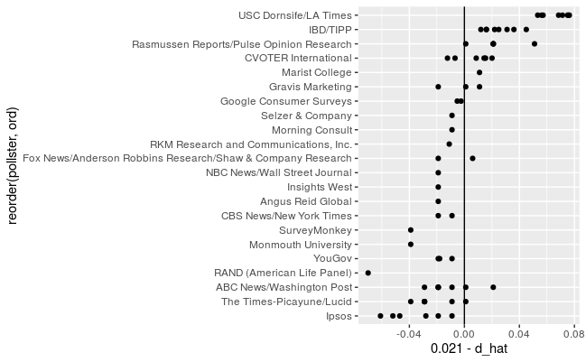

```r
d=0.021
k <- polls %>% group_by(pollster) %>% summarize(ord = sum(d-d_hat))
polls %>% merge(k, key = pollster, how = "inner") %>%
  ggplot() +
  geom_point(aes(x=0.021-d_hat, y = reorder(pollster, ord))) +
  geom_vline(xintercept=0)
```

10. Redo the plot that you made for exercise 9, but only for pollsters that took five or more polls.

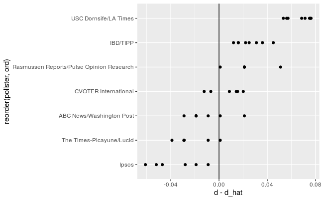

```r
pollsters <- count(polls, pollster) %>% filter(n >= 5) %>% .$pollster
k <- polls %>% group_by(pollster) %>% summarize(ord = sum(d-d_hat))
polls %>%
  merge(k, key = pollster, how = "inner") %>%
  filter(pollster %in% pollsters) %>%
  ggplot() +
  geom_point(aes(x=d-d_hat, y = reorder(pollster, ord))) +
  geom_vline(xintercept=0)
```

## 15.8 Power

Pollsters are not successful at providing correct confidence intervals, but rather at predicting who will win. When we took a 25 bead sample size, the confidence interval for the spread:

```r
N <- 25
x_hat <- 0.48
(2 * x_hat - 1) + c(-1.96, 1.96) * 2 * sqrt(x_hat * (1 - x_hat) / N)
```

[output not shown]

A problem with our poll results is that given the sample size and the value of  
p, we would have to sacrifice on the probability of an incorrect call to create an interval that does not include 0. This does not mean that the election is close. It only means that we have a small sample size. In statistical textbooks this is called lack of power. In the context of polls, power is the probability of detecting spreads different from 0. By increasing our sample size, we lower our standard error and therefore have a much better chance of detecting the direction of the spread.

## 15.9 p-values

p-values are ubiquitous in the scientific literature. They are related to confidence intervals so we introduce the concept here. Let’s consider the blue and red beads. Suppose that rather than wanting an estimate of the spread or the proportion of blue. We want to know if the spread
2p-1>0. For example, if we observed 52 blue beads for N=100, than $2\bar{X}-1=0.04$. This seems to be pointing to the existence of more blue than red beads since 0.04 is larger than 0. But we know there is chance involved in this process and we could get a 52 even when the actual spread is 0. We call the assumption that the spread is s2p-1=0 a null hypothesis. The null hypothesis is the skeptic’s hypothesis. We have observed a random variable $2\bar{X}-1=0.04$ and the p-value is the answer to the question: how likely is it to see a value this large, when the null hypothesis is true? For
$$P(|\bar{X}-0.5|>0.02)$$
assuming the 2p-1=0 or p=0.5Under the null hypothesis we know that:
$$\sqrt{N}\frac{\bar{X}-0.5}{\sqrt{0.5\cdot(1-0.5)}}$$
is standard normal. We therefore can compute the probability above, which is the p-value.
$$P\left(\sqrt{N}\frac{\bar{X}-0.5}{\sqrt{0.5\cdot(1-0.5)}}>\sqrt{N}\frac{0.02}{\sqrt{0.5\cdot(1-0.5)}}\right)$$

```r
N <- 100
z <- sqrt(N)*0.02/0.5
1 - (pnorm(z) - pnorm(-z))
```

In this case, there is actually a large chance of seeing 52 or larger under the null hypothesis. Keep in mind that there is a close connection between p-values and confidence intervals. If a 95% confidence interval of the spread does not include 0, we know that the p-value must be smaller than 0.05.

## 15.10 Association tests

The statistical tests we have studied up to now leave out a substantial portion of data types. Specifically, we have not discussed inference for binary, categorical, and ordinal data. A 2014 PNAS paper analyzed success rates from funding agencies in the Netherlands and concluded that the results reveal gender bias. The main evidence for this conclusion comes down to a comparison of the percentages. Table S1 in the paper includes the information we need. Here are the three columns showing the overall outcomes:

```r
data("research_funding_rates")
research_funding_rates %>% select(discipline, applications_total,
                                  success_rates_total) %>% head()
```

We have these values for each gender:

```r
names(research_funding_rates)
```

We can compute the totals that were successful and the totals that were not as follows:

```r
totals <- research_funding_rates %>%
  select(-discipline) %>%
  summarize_all(sum) %>%
  summarize(yes_men = awards_men,
            no_men = applications_men - awards_men,
            yes_women = awards_women,
            no_women = applications_women - awards_women)
```

```r
totals %>% summarize(percent_men = yes_men/(yes_men+no_men),
                     percent_women = yes_women/(yes_women+no_women))
```

But could this be due just to random variability? Here we learn how to perform inference for this type of data.

### 15.10.1 Lady Tasting Tea

R.A. Fisher was one of the first to formalize hypothesis testing. The “Lady Tasting Tea” is one of the most famous examples. The story is as follows: an acquaintance of Fisher’s claimed that she could tell if milk was added before or after tea was poured. Fisher was skeptical. He designed an experiment to test this claim. He gave her four pairs of cups of tea: one with milk poured first, the other after. The order was randomized. The null hypothesis here is that she is guessing. Fisher derived the distribution for the number of correct picks on the assumption that the choices were random and independent. As an example, suppose she picked 3 out of 4 correctly. Do we believe she has a special ability? The basic question we ask is: if the tester is actually guessing, what are the chances that she gets 3 or more correct? Just as we have done before, we can compute a probability under the null hypothesis that she is guessing 4 of each. Under this null hypothesis, we can think of this particular example as picking 4 balls out of an urn with 4 blue (correct answer) and 4 red (incorrect answer) balls. Remember, she knows that there are four before tea and four after. Under the null hypothesis that she is simply guessing, each ball has the same chance of being picked. We can then use combinations to figure out each probability. The probability of picking 3 is $\frac{\binom{4}{3}\cdot\binom{4}{1}}{\binom{8}{4}}=\frac{16}{70}$. The probability of picking all 4 correct is $\frac{\binom{4}{4}\cdot\binom{4}{0}}{\binom{8}{4}}=\frac{1}{70}$. Thus, the chance of observing a 3 or something more extreme, under the null hypothesis, is $$0.24. This is the p-value. The procedure that produced this p-value is called Fisher’s exact test and it uses the hypergeometric distribution.

### 15.10.2 Two-by-two tables

The data from the experiment is usually summarized by a table like this:

```r
tab <- matrix(c(3,1,1,3),2,2)
rownames(tab)<-c("Poured Before","Poured After")
colnames(tab)<-c("Guessed before","Guessed after")
tab
```

These are referred to as a two-by-two table. For each of the four combinations one can get with a pair of binary variables, they show the observed counts for each occurrence.

The function fisher.test performs the inference calculations above:

```r
fisher.test(tab, alternative="greater")$p.value
```

### 15.10.3 Chi-square Test

Notice that, in a way, our funding rates example is similar to the Lady Tasting Tea. However, in the Lady Tasting Tea example, the number of blue and red beads is experimentally fixed and the number of answers given for each category is also fixed. This is because Fisher made sure there were four cups with milk poured before tea and four cups with milk poured after and the lady knew this, so the answers would also have to include four befores and four afters. If this is the case, the sum of the rows and the sum of the columns are fixed. This defines constraints on the possible ways we can fill the two by two table and also permits us to use the hypergeometric distribution. In general, this is not the case. Nonetheless, there is another approach, the Chi-squared test, which is described below. Imagine we have 290, 1,345, 177, 1,011 applicants, some are men and some are women and some get funded, whereas others don’t. We saw that the success rates for men and woman were:

```r
totals %>% summarize(percent_men = yes_men/(yes_men+no_men),
                     percent_women = yes_women/(yes_women+no_women))
```

respectively. Would we see this again if we randomly assign funding at the overall rate:

```r
rate <- totals %>%
  summarize(percent_total =
              (yes_men + yes_women)/
              (yes_men + no_men +yes_women + no_women)) %>%
  pull(percent_total)
rate
```

The Chi-square test answers this question. The first step is to create the two-by-two data table:

```r
two_by_two <- data.frame(awarded = c("no", "yes"),
                     men = c(totals$no_men, totals$yes_men),
                     women = c(totals$no_women, totals$yes_women))
two_by_two
```

The general idea of the Chi-square test is to compare this two-by-two table to what you expect to see, which would be:

```r
data.frame(awarded = c("no", "yes"),
       men = (totals$no_men + totals$yes_men) * c(1 - rate, rate),
       women = (totals$no_women + totals$yes_women) * c(1 - rate, rate))
```

We can see that more men than expected and fewer women than expected received funding. However, under the null hypothesis these observations are random variables. The Chi-square test tells us how likely it is to see a deviation this large or larger. This test uses an asymptotic result, similar to the CLT, related to the sums of independent binary outcomes. The R function `chisq.test` takes a two-by-two table and returns the results from the test:

```r
chisq_test <- two_by_two %>% select(-awarded) %>% chisq.test()
```

```r
chisq_test$p.value
```

[output not shown]

### 15.10.4 The odds ratio

An informative summary statistic associated with two-by-two tables is the odds ratio. Define the two variables as X=1 if you are a male and 0 otherwise, and Y=1 if you are funded and 0 otherwise. The odds of getting funded if you are a man is defined:
$$\frac{P(Y=1\mid X=1)}{P(Y=0\mid X=1)}$$
and can be computed like this:

```r
odds_men <- with(two_by_two, (men[2]/sum(men)) / (men[1]/sum(men)))
odds_men
```

And the odds of being funded if you are a woman is:
$$\frac{P(Y=1\mid X=0)}{P(Y=0\mid X=0)}$$
and can be computed like this:

```r
odds_women <- with(two_by_two, (women[2]/sum(women)) / (women[1]/sum(women)))
odds_women
```

The odds ratio is the ratio for these two odds: how many times larger are the odds for men than for women?

```r
odds_men / odds_women
```

We often see two-by-two tables written out as

|  | Men | Women |
| --- | --- | --- |
| Awarded | a | b |
| Not Awarded | c | d |

In this case, the odds ratio is $\frac{\frac{a}{c}}{\frac{b}{d}}=\frac{ad}{bc}$

### 15.10.5 Confidence intervals for the odds ratio

Computing confidence intervals for the odds ratio is not mathematically straightforward. Unlike other statistics, for which we can derive useful approximations of their distributions, the odds ratio is not only a ratio, but a ratio of ratios. Therefore, there is no simple way of using, for example, the CLT. However, statistical theory tells us that when all four entries of the two-by-two table are large enough, then the log of the odds ratio is approximately normal with standard error
$$\sqrt{\frac{1}{a}+\frac{1}{b}+\frac{1}{c}+\frac{1}{d}}$$

This implies that a 95% confidence interval for the log odds ratio can be formed by:
$$\log(\frac{ad}{bc})\pm1.96\sqrt{\frac{1}{a}+\frac{1}{b}+\frac{1}{c}+\frac{1}{d}}$$

By exponentiating these two numbers we can construct a confidence interval of the odds ratio.

Using R we can compute this confidence interval as follows:

```r
log_or <- log(odds_men / odds_women)
se <- two_by_two %>% select(-awarded) %>%
  summarize(se = sqrt(sum(1/men) + sum(1/women))) %>%
  pull(se)
ci <- log_or + c(-1,1) * qnorm(0.975) * se
```

If we want to convert it back to the odds ratio scale, we can exponentiate:

```r
exp(ci)
```

Note that 1 is not included in the confidence interval which must mean that the p-value is smaller than 0.05. We can confirm this using:

```r
2*(1 - pnorm(log_or, 0, se))
```

This is a slightly different p-value than that with the Chi-square test. This is because we are using a different asymptotic approximation to the null distribution. To learn more about inference and asymptotic theory for odds ratio, consult the Generalized Linear Models book by McCullagh and Nelder.

### 15.10.6 Small count correction

Note that the log odds ratio is not defined if any of the cells of the two-by-two table is 0. This is because if a, b, c, or d is 0, the $\log(\frac{ad}{bc})$ is either the log of 0 or has a 0 in the denominator. For this situation, it is common practice to avoid 0s by adding 0.5 to each cell. This is referred to as the Haldane–Anscombe correction and has been shown, both in practice and theory, to work well.

### 15.10.7 Large samples, small p-values

As mentioned earlier, reporting only p-values is not an appropriate way to report the results of data analysis. In scientific journals, for example, some studies seem to overemphasize p-values. Some of these studies have large sample sizes and report impressively small p-values. Yet when one looks closely at the results, we realize odds ratios are quite modest: barely bigger than 1. In this case the difference may not be practically significant or scientifically significant.

Note that the relationship between odds ratio and p-value is not one-to-one. It depends on the sample size. So a very small p-value does not necessarily mean a very large odds ratio. Notice what happens to the p-value if we multiply our two-by-two table by 10, which does not change the odds ratio:

```r
two_by_two %>% select(-awarded) %>%
  mutate(men = men*10, women = women*10) %>%
  chisq.test() %>% .$p.value
```

## 15.11 Exercises

1. A famous athlete has an impressive career, winning 70% of her 500 career matches. However, this athlete gets criticized because in important events, such as the Olympics, she has a losing record of 8 wins and 9 losses. Perform a Chi-square test to determine if this losing record can be simply due to chance as opposed to not performing well under pressure.

```r
x <- matrix(c(150, 9, 350, 8), 2, 2)
chisq.test(x)$p.value
```

2. Why did we use the Chi-square test instead of Fisher’s exact test in the previous exercise? c
1. It actually does not matter, since they give the exact same p-value.
2. Fisher’s exact and the Chi-square are different names for the same test.
3. Because the sum of the rows and columns of the two-by-two table are not fixed so the hypergeometric distribution is not an appropriate assumption for the null hypothesis. For this reason, Fisher’s exact test is rarely applicable with observational data.
4. Because the Chi-square test runs faster.
3. Compute the odds ratio of “losing under pressure” along with a confidence interval.

```r
c(log(8*150 / (350*9)) - 1.96 * sqrt(1/350 + 1/8 + 1/150 + 1/9),
  log(8*150 / (350*9)) + 1.96 * sqrt(1 / 350 + 1 / 8 + 1 / 150 + 1 / 9))
```

4. Notice that the p-value is larger than 0.05 but the 95% confidence interval does not include 1. What explains this? b
1. We made a mistake in our code.
2. These are not t-tests so the connection between p-value and confidence intervals does not apply.
3. Different approximations are used for the p-value and the confidence interval calculation. If we had a larger sample size the match would be better.
4. We should use the Fisher exact test to get confidence intervals.
5. Multiply the two-by-two table by 2 and see if the p-value and confidence retrieval are a better match.

```r
x <- matrix(c(150, 9, 350, 8), 2, 2)
chisq.test(x*2)$p.value

c(log(8*150 / (350*9)) - 1.96 * sqrt(2*(1/350 + 1/8 + 1/150 + 1/9)),
  log(8*150 / (350*9)) + 1.96 * sqrt(2*(1/350 + 1/8 + 1/150 + 1/9)))
```